# TP de modélisation °3 - M1 SdM

Intégration et Dynamique de populations sous R

Sakina-Dorothée Ayata (sakina-dorothee.ayata@locean.ipsl.fr) Séance assurée par Emilienne Grzegorczyk (emilienne.grzegorczyk@mnhn.fr)

13 Novembre 2026

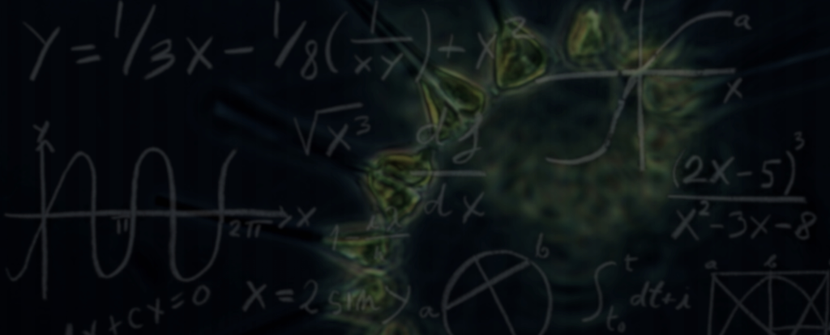

Cette séance vous permettra de simuler la dynamique proie-prédateur entre du phytoplancton (que l’on notera “P”) et du zooplankton (que l’on notera “Z”). Nous implémenterons des modèles de type Lotka-Volterra avec R sous RStudio. Nous utiliserons plusieurs méthodes d’intégration numérique (= plusieurs manières de résoudre les équations du modèle), soit avec l’intégration d’Euler, soit avec la fonction *lsoda*, ensuivant ce que nous avions déjà fait lors du premier TP. Cette fois, il n’y aura plus une seule variable (et donc une seule équation à résoudre), mais deux variables en intéraction : les variations de l’une dépendront des valeurs de l’autre, et réciproquement. Il y a aura donc 2 équations à résoudre simultanément. On parle de “système d’équations”.

Tous les scripts de correction vous seront présentés et expliqués au fur et à mesure de la séance.

# Exercice 1 : Simuler le modèle de Lotka-Volterra

Nous allons ainsi simuler la dynamique d’une population de proie (P) et d’une population de prédateur (Z) suivant le modèle de Lotka-Volterra : - Dynamique de la proie P : dP/dt = + r.P - a.P.Z - Dynamique du prédateur Z : dZ/dt = + e.a.P.Z - m.Z

La proie P a une croissance exponentielle (taux de croissance : r) mais est consommée par un prédateur Z (relation linéaire, taux de prédation : a). Quant au prédateur, il croit grâce à la prédation de manière linéaire (efficacité de la croissance par prédation : e) et a une mortalité linaire (taux de mortalité : m).

Suivez pas à par le script ci-dessous et n’hésitez pas à me poser des questions.

### Définition des paramètres et de plusieurs tableaux

Voici par exemple les paramètres et variables dont vous aurez besoin :

```r
# Defining the model parameters
r <- 0.5  # growth rate of the phytoplankton (d-1)
a <- 0.1  # predation rate of the zooplankton feeding on phytoplankton (d-1m3gC-1)
e <- 0.9  # efficiency of the predation (unitless)
m <- 0.5  # mortality rate of zooplankton (d-1)

# Declaring the model time steps

t0 <- 0   #initial time
dt <- 0.01 # time step
tf <- 40  #final time
times <- seq(from=t0, to=tf, by=dt) # time vector
n <- length(times) # size of the time vector: we will use C later

# Here, have a look at the vector called "times": how is it structured/organised? What does it contain?
# What is n?

# Declaring the vector for the concentrations of phyto and zoo
mespop <- matrix(0, nrow = 2, ncol = n)

# Again, have a look at the vector called "mespop": how is it structured/organised? What does it contain?


# Declaring the initial values for the phyto and the zoo

mespop[1,1] <- 12  # Initial density of phytoplankton (gC/m3)
mespop[2,1] <- 6   # Initial density of zooplankton (gC/m3)
```

Prenez le temps de regarder ce que continnent les différentes variables que vous venez de définir : que représent ces variables ? Est-ce des valeurs uniques ? Des vecteurs ? Des tableaux avec des lignes et des colonnes ?

Nous allons maintenant écrire les équations du modèles puis les résoudre, d’abord avec la méthode d’Euler, ensuite grâce à la fonction lsoda.

### Option 1 : Intégration numérique selon la méthode d’Euler (à la main)

Commençons par appliquer la méthode d’Euler, à la main, pour remplir le tableau qui contient les concentrations en phyto et en zoo au fur et à mesure de chaque pas de temps. Pour ça, on utilise une boucle “pour”.

A vous de jouer !

Regardez ensuite ce que contient le tableau mespop.

Nous allons maintenant tracer l’évolution temporelle de phyto et de zoo au cours du temps.

### Graphiques

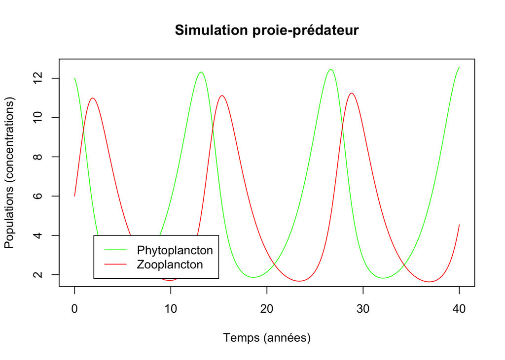

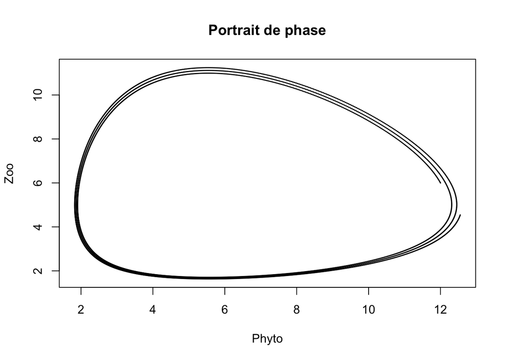

Que constatez-vous ? Pourquoi n’obtenez vous pas un cercle parfait ? A quoi est-ce du ? Comment faire pour éviter ça ? (plusieurs manières)

### A vour de jouer !

*Exercice* : simulez le modèle en utilisant la fonction *lsoda* puis tracez vos résultats.

Vous allez maintenant implémenter le même modèle mais cette fois en utilisant la fonction *lsoda* du package *deSolve* (https://desolve.r-forge.r-project.org/). Si ce n’est pas déjà fait, vous devrez installer le package avant de le charger.

Pour simuler ce modèle avec R, il faut fournir à R : 1) les paramètres du modèle (on peut les écrire sous la forme d’un vecteur) 2) les conditions initiales (valeurs des variables au départ) 3) le modèle écrit comme une fonction R (décrivant l’évolution des variables, i.e. leurs dérivées) 4) un algorithme d’intégration numérique (pour intégrer les équations du modèles), ici lsoda 5) afficher les résultats (ici avec ggplot2)

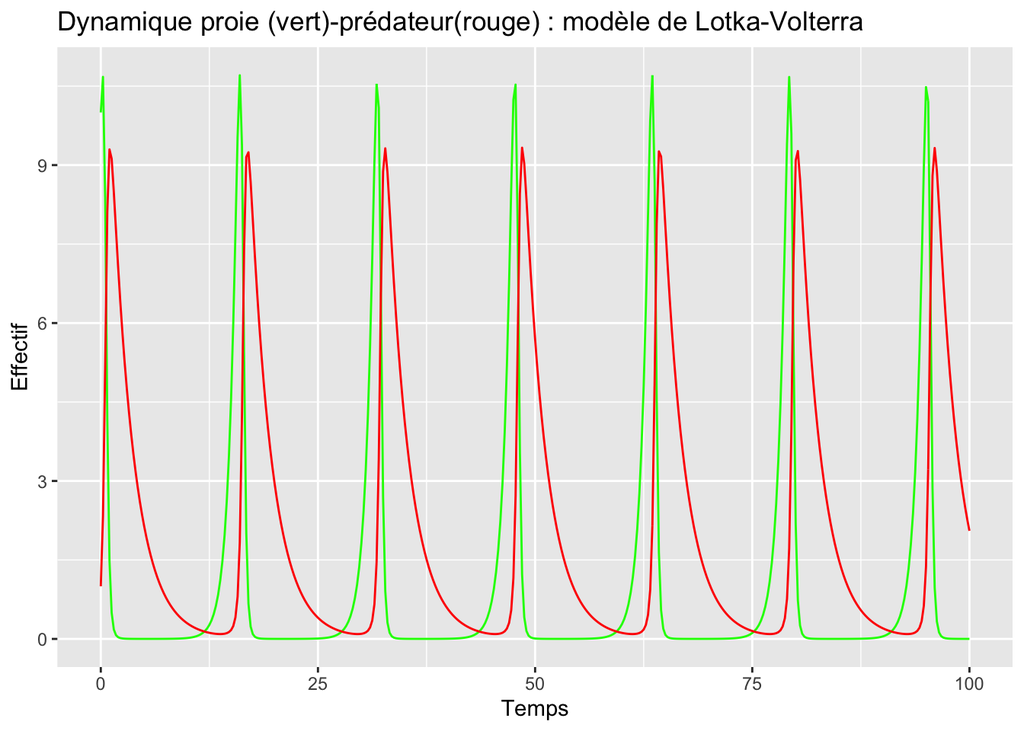

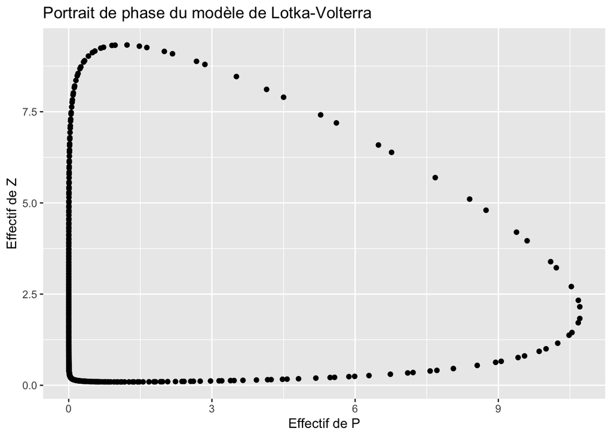

A vous de jouer !

Tracez ensuite vos résultats (avec plot ou ggplot) et commentez-les. Qu’obtenez-vous ? Qu’est-ce que ça veut dire quant aux éventuelles erreurs d’intégration ?

# Exercice 2 : Simuler le modèle de Lotka-Volterra avec une croissance logistique pour la proie

Vous devrez définir de nouveaux paramètres et modifier les équations de votre modèle…

A vous de jouer ici !

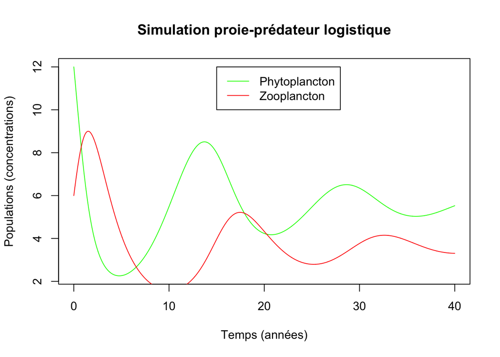

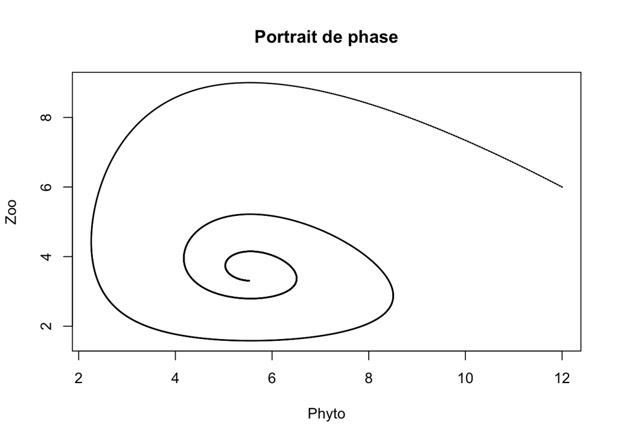

Qu’observez-vous ?

Que pouvez-vous dire sur le type d’équilibre obtenu ?

Implémentez le modèle avec deSolve et lsoda : A vous de jouer !

# Exercice 3 : Simuler le modèle de Lotka-Volterra avec une saturation de la prédation

Dans le modèle de Lotka-Volterra de base, toutes les relations sont linéaires. Or ce n’est pas très réalise d’avoir de la prédation linéaire, car plus le prédateur mange plus il est rassasié. A votre avis comment pourrions-nous le représenter ? Par quoi faudrait-il remplacer cette relation linéaire ? Souvenez-vous des réponses fonctionnelles proposées par Holling. Que choisiriez-vous ?

A vous de jouer !

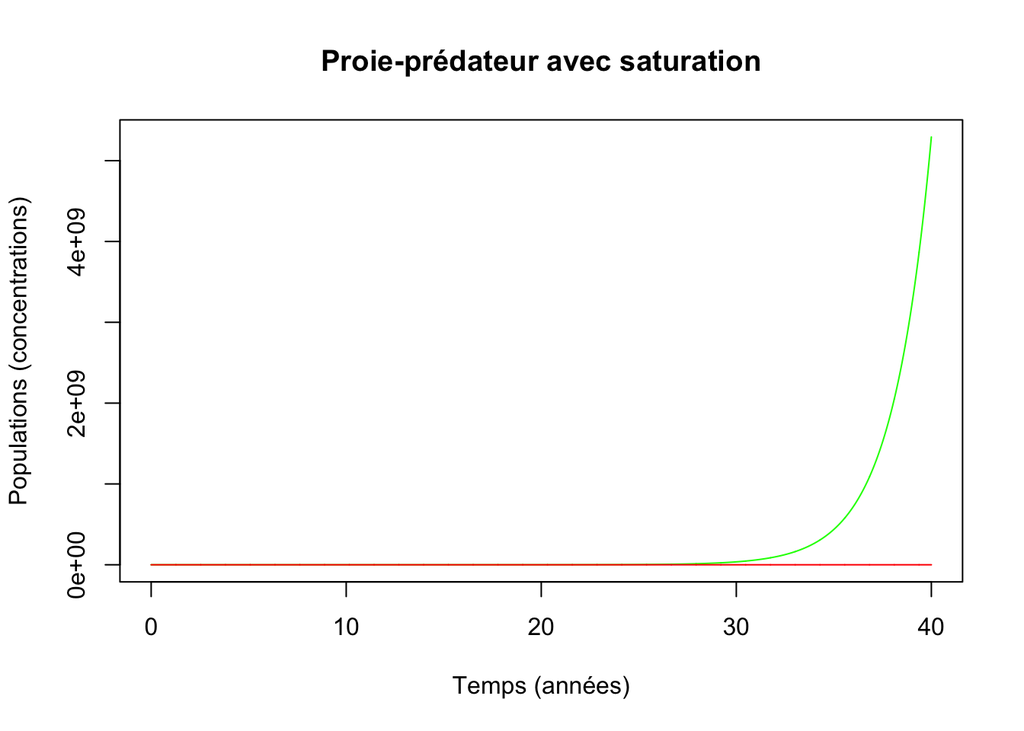

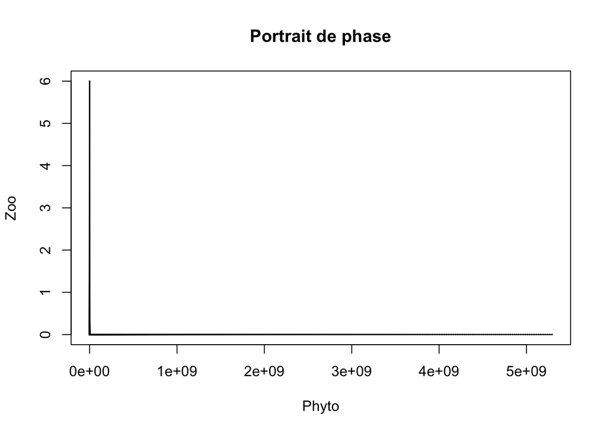

Décrivez les résultats obtenus. Que devient le zoo ? Que devient le phyto ? Que pensez-vous ? Est-ce que ceci vous semble plus réaliste ?

Pensez-vous que l’équilibre est stable ?

# Exercice 4 : Simuler le modèle de Lotka-Volterra avec une mortalité densité-dépendante pour le prédateur

Dans le modèle de Lotka-Volterra de base, toutes les relations sont linéaires. Or ce n’est pas très réalise d’avoir de la mortalité linéaire, car plus il y a de prédateurs, plus sa mortalité augmente. On parle de mortalité densité-dépendante. Comment représsenter ça dans le modèle ?

A vous de jouer !

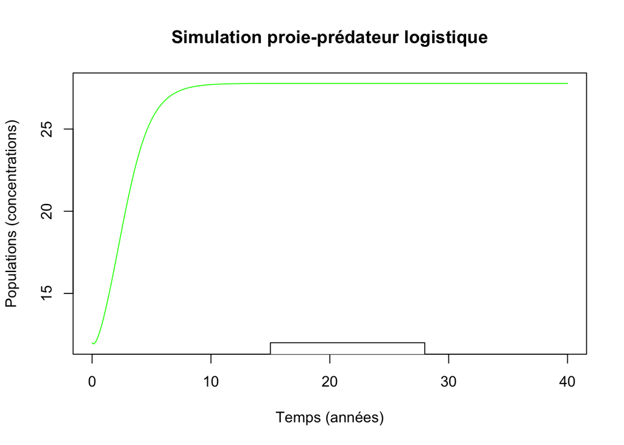

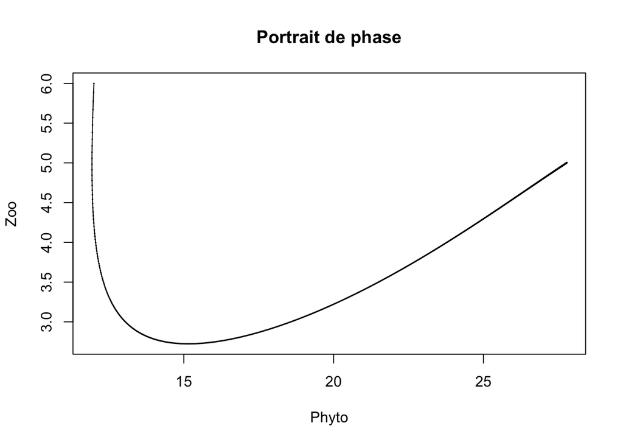

Qu’observez-vous ?

Quel est le type d’équilibre obtenu ?

# Exercice 4bis : Simuler le modèle de Lotka-Volterra avec une saturation de la prédation (bis)

Nous allons maintenant un peu changer les valeurs des paramètres et voir le comportement du modèle change.

A vous de jouer !

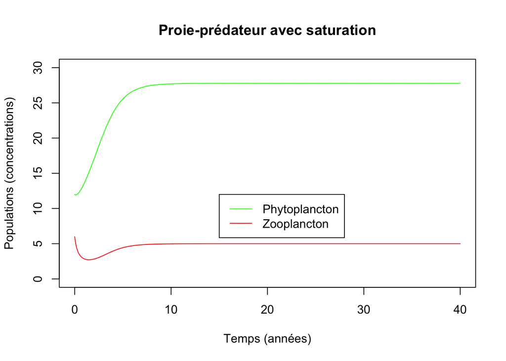

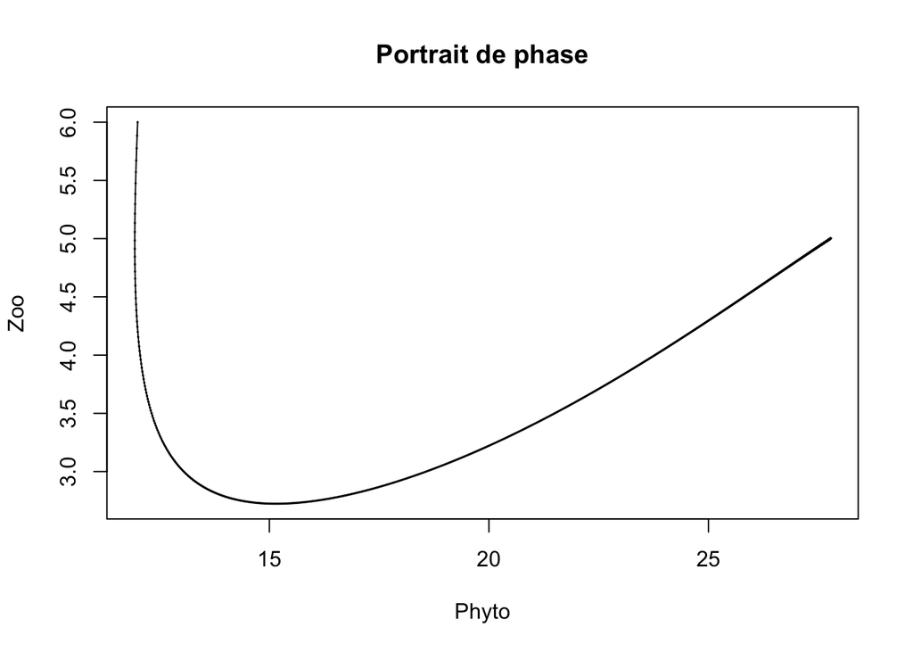

Quel type d’équilibre obtenez-vous ? Et si m vaut 0.3, qu’obtenez-vous ? Quel est le type d’équilibre ?

# Exercice 5 : Simuler le modèle de Lotka-Volterra avec 3 niveaux trophiques

Nous allons maintenant un peu changer les valeurs des paramètres et voir le comportement du modèle change.

A vous de jouer !

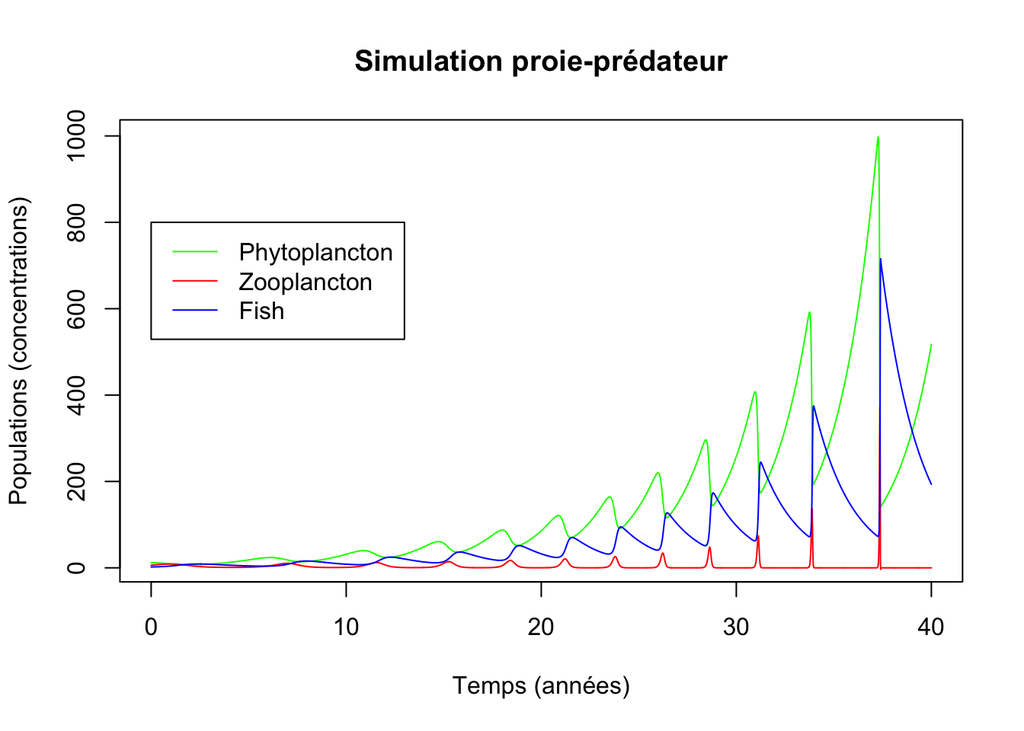

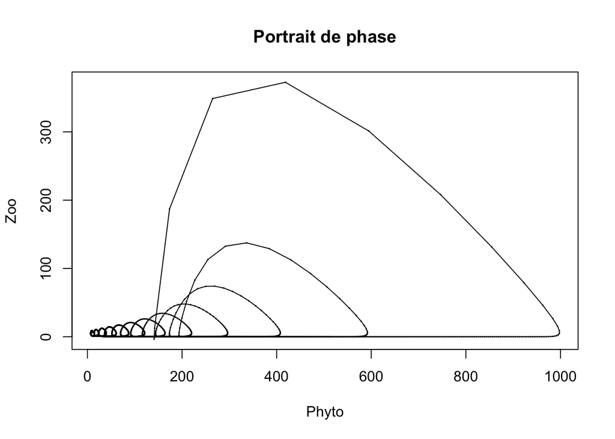

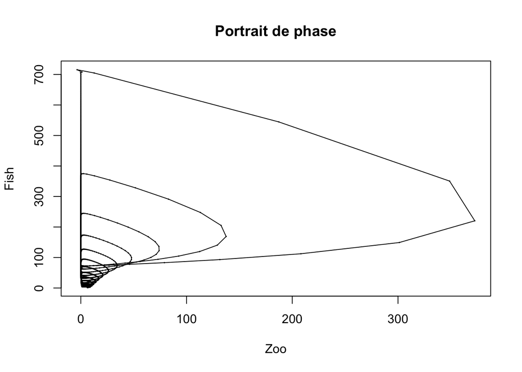

Que constatez vous ??

Est-ce que le modèle est stable ?

Et que se passe-t-il pour une mortalité quadratiques des poissons ?

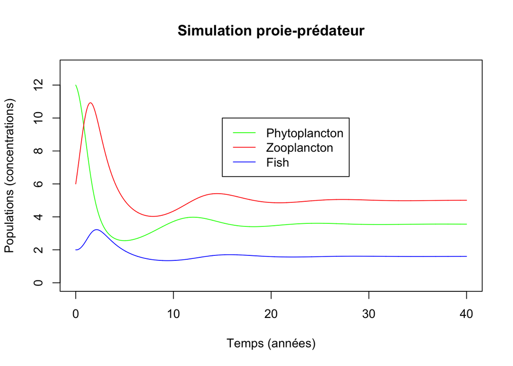

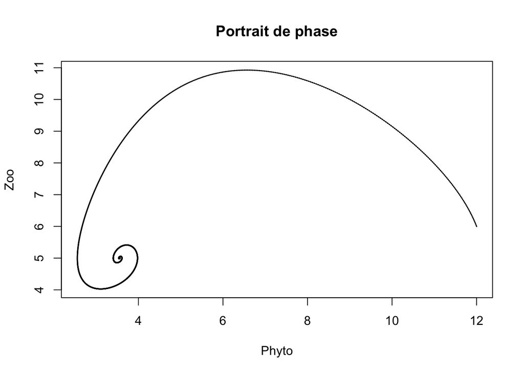

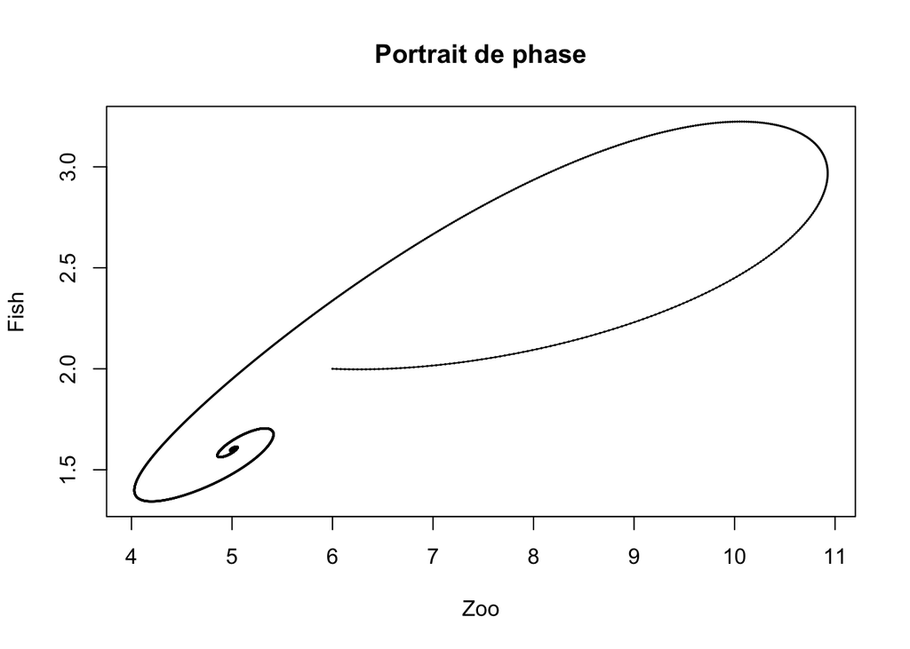

Que constatez vous ??

Surtout si vous avez des questions, n’hésitez pas à me solliciter.

Bonnes simulations !